# Illustrative example for `hawkes` package.

Peter F Halpin

5/10/2017

This is a minimal example of using the code in the `hawkes` package. The package is in very preliminary stages of development. The main functions are illustrated here. See the documentation for a full list functions and issues.

First install and load the package.

```r
devtools::install_github("peterhalpin/hawkes")
library("hawkes")
```

It comes with an example dataset, `email`, which is a list of two vectors containing the sendings times of email exchanges between an employer and employee. Time is recorded in hours and the employee’s start date is `t = 0`. See Halpin & DeBoeck (2013) for more details. The function `pp` takes a list of event times and turns it into an S3 object with some basic functionality.

```r
pp_obj <- pp(email)
print(pp_obj)
```

[output not shown]

[output cut: 53 more lines]

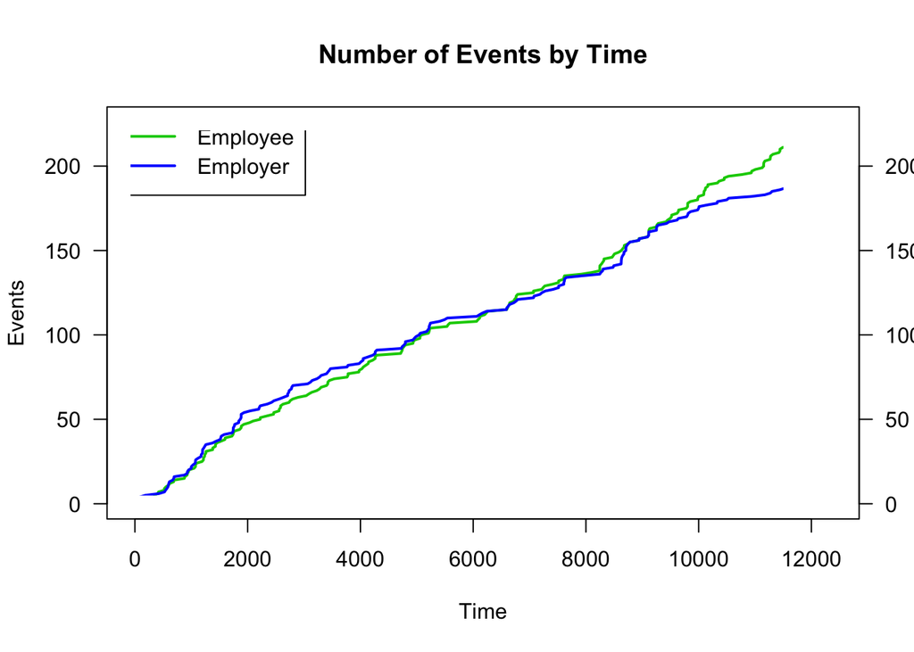

```r
plot(pp_obj)
```

The `gof` function can be used to visually inspect the data for temporal clustering (i.e., overdispersion relative to the homogeneous Poisson process). See `help(gof)` for more details.

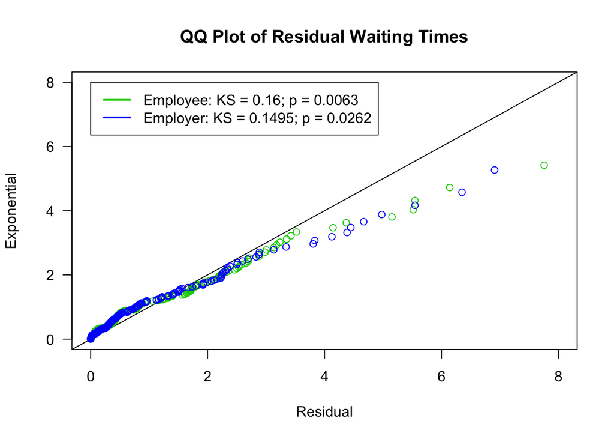

```r
gof(pp_obj)
```

The clustering might be accounted for using the Hawkes process. To esimtate the model use the `EM` function and see `help(EM)` for a description. (This will take a while to run and the `optim` trace output will print to the console. Using just a few iterations for this e.g.)

```r
hawkes_em <- EM(pp_obj, nstarts = 1, maxit = 3)
```

Check out EM output:

```r
hawkes_em
```

```
## $Solutions
##          logL           mu1           mu2        alpha1        alpha2
## -1.960919e+03  1.310248e-02  7.448683e-03  1.014256e-01  3.874521e-01
##        alpha3        alpha4      k_parm11      k_parm12      k_parm13
##  2.128727e-01  8.312776e-02  1.368367e+00  7.923394e-01  9.230438e-01
##      k_parm14      k_parm21      k_parm22      k_parm23      k_parm24
##  7.781612e-01  5.501924e-01  2.168166e-01  3.299156e-01  1.054655e+00
##
## $History
##     iter0     iter1     iter2     iter3
## -2268.630 -2032.870 -1987.908 -1960.919
```

Use the `get_parms` function to extract and format Solutions from `EM` and then call the `gof` function with the parms to assess whether the model accounted for the clustering in the data.

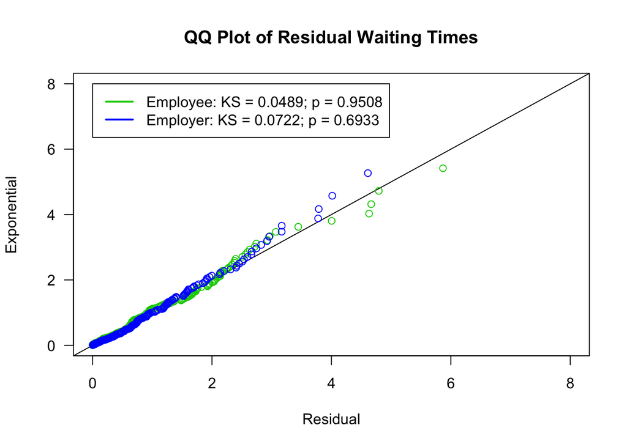

```r
parms <- get_parms(hawkes_em)
gof(pp_obj, parms)
```

Check back soon for data simulation, computation of standard errors, choice of response kernels, and other functionality currently under development.